# XAI - Exercise 5: Partial Dependence Plots (PDP)

Pablo Huguet

2026-05-10

# Librerías

```r
library(randomForest)
library(pdp)
library(ggplot2)
library(dplyr)
library(gridExtra)
```

# Exercise 1 – 1D Partial Dependence Plot: Bike Rentals

## Data & Model

```r
day <- read.csv("day.csv")

# Features used for training
features <- c("instant", "temp", "hum", "windspeed",
               "season", "yr", "mnth", "holiday",
               "weekday", "workingday", "weathersit", "atemp")

set.seed(42)
rf_bike <- randomForest(
  x = day[, features],
  y = day$cnt,
  ntree = 200,
  importance = TRUE
)

cat("R² =", round(1 - rf_bike$mse[200] / var(day$cnt), 4))
```

```
## R² = 0.8914
```

## PDP Plots

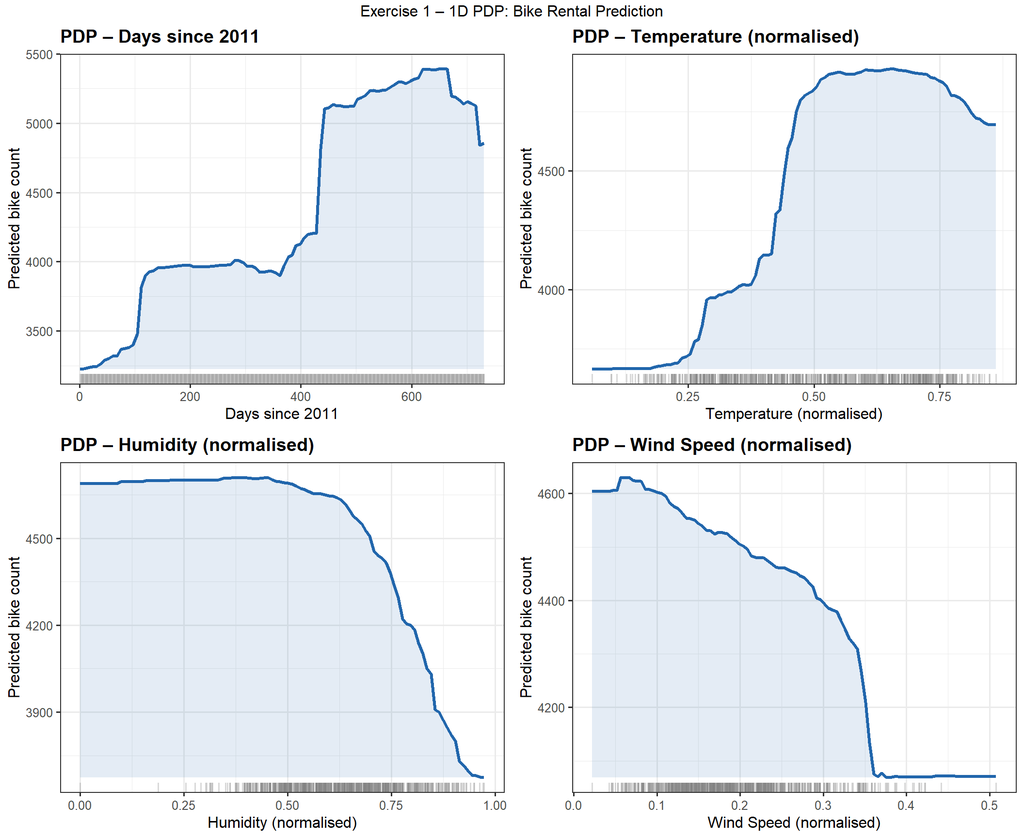

```r
plot_pdp_bike <- function(feature, label) {
  pd <- partial(rf_bike, pred.var = feature, train = day[, features], grid.resolution = 100)
  ggplot(pd, aes_string(x = feature, y = "yhat")) +
    geom_line(color = "#2166AC", linewidth = 1.2) +
    geom_ribbon(aes(ymin = min(yhat), ymax = yhat), alpha = 0.12, fill = "#2166AC") +
    geom_rug(data = day, aes_string(x = feature), sides = "b",
             inherit.aes = FALSE, alpha = 0.3, color = "gray50") +
    labs(title = paste("PDP –", label),
         x = label, y = "Predicted bike count") +
    theme_bw(base_size = 12) +
    theme(plot.title = element_text(face = "bold"))
}

p1 <- plot_pdp_bike("instant",   "Days since 2011")
p2 <- plot_pdp_bike("temp",      "Temperature (normalised)")
p3 <- plot_pdp_bike("hum",       "Humidity (normalised)")
p4 <- plot_pdp_bike("windspeed", "Wind Speed (normalised)")

grid.arrange(p1, p2, p3, p4, ncol = 2,
             top = "Exercise 1 – 1D PDP: Bike Rental Prediction")
```

## Analysis

**Temperature:** Strong positive effect up to ~0.6 (normalised, ≈20°C), after which the curve flattens and slightly decreases. Very high temperatures discourage cycling — an inverted-U pattern consistent with seasonal behaviour.

**Humidity:** Clear negative relationship. As humidity rises above 0.6, predicted rentals drop noticeably. The effect becomes most pronounced above 0.8, suggesting non-linear sensitivity to discomfort.

**Wind Speed:** Moderate negative effect across the observed range. High wind conditions make cycling physically harder, particularly for casual riders.

# Exercise 2 – 2D Partial Dependence Plot: Humidity × Temperature

## 2D PDP

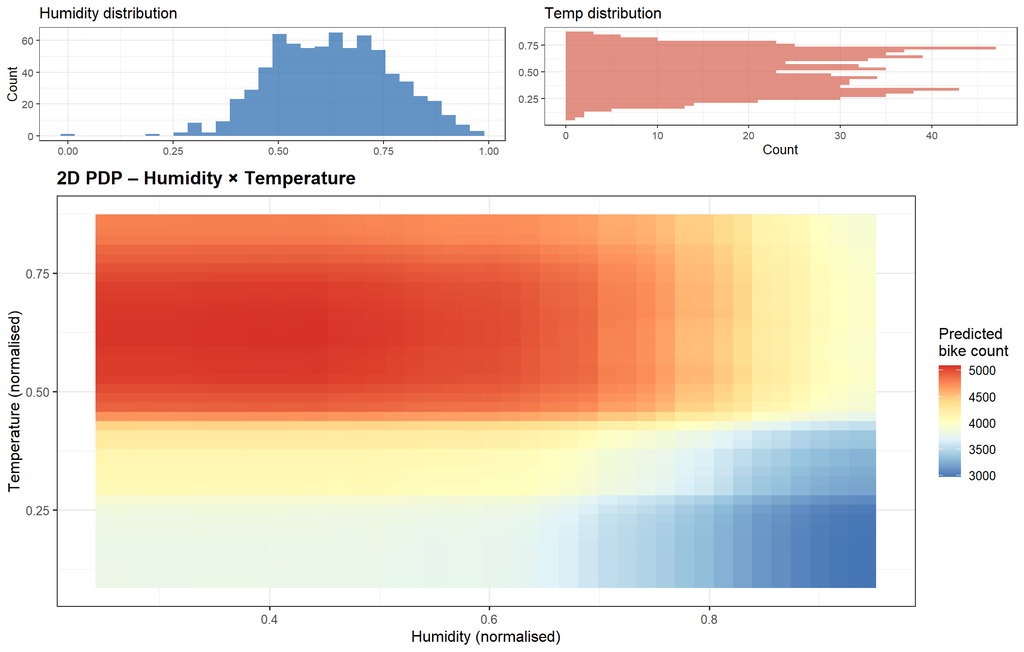

```r
set.seed(42)
sample_day <- day %>% sample_n(300)

pd_2d <- partial(rf_bike,
                 pred.var = c("hum", "temp"),
                 train = sample_day[, features],
                 grid.resolution = 40)

# Main 2D tile plot
main_plot <- ggplot(pd_2d, aes(x = hum, y = temp, fill = yhat)) +
  geom_tile(width = 0.025, height = 0.025) +
  scale_fill_distiller(palette = "RdYlBu", direction = -1,
                       name = "Predicted\nbike count") +
  labs(title = "2D PDP – Humidity × Temperature",
       x = "Humidity (normalised)", y = "Temperature (normalised)") +
  theme_bw(base_size = 12) +
  theme(plot.title = element_text(face = "bold"))

# Density plots for context
top_hist <- ggplot(day, aes(x = hum)) +
  geom_histogram(fill = "#2166AC", alpha = 0.7, bins = 30) +
  labs(title = "Humidity distribution", x = NULL, y = "Count") +
  theme_bw(base_size = 10)

right_hist <- ggplot(day, aes(x = temp)) +
  geom_histogram(fill = "#D6604D", alpha = 0.7, bins = 30) +
  coord_flip() +
  labs(title = "Temp distribution", x = NULL, y = "Count") +
  theme_bw(base_size = 10)

grid.arrange(top_hist, right_hist, main_plot,
             layout_matrix = rbind(c(1, 2), c(3, 3)),
             heights = c(1, 3))
```

## Interpretation

The 2D PDP reveals an important interaction between temperature and humidity. **Highest predicted rentals** are concentrated in moderate-to-high temperature (0.4–0.7) combined with low-to-moderate humidity (0.2–0.6) — pleasant cycling conditions.

Both the bottom-right region (low temperature, high humidity) and top-right (high temperature, high humidity) show suppressed demand. Temperature is the dominant factor: even at high humidity, moderate temperatures maintain reasonable predicted counts.

The density plots confirm data is concentrated in moderate ranges, so predictions in extreme corners should be interpreted cautiously.

# Exercise 3 – 1D PDP: House Price Prediction

## Data & Model

```r
kc <- read.csv("kc_house_data.csv")

features_house <- c("bedrooms", "bathrooms", "sqft_living",
                    "sqft_lot", "floors", "yr_built")

set.seed(42)
kc_sample <- kc %>% sample_n(3000)

rf_house <- randomForest(
  x = kc_sample[, features_house],
  y = kc_sample$price,
  ntree = 200
)

cat("R² =", round(1 - rf_house$mse[200] / var(kc_sample$price), 4))
```

```
## R² = 0.5699
```

## PDP Plots

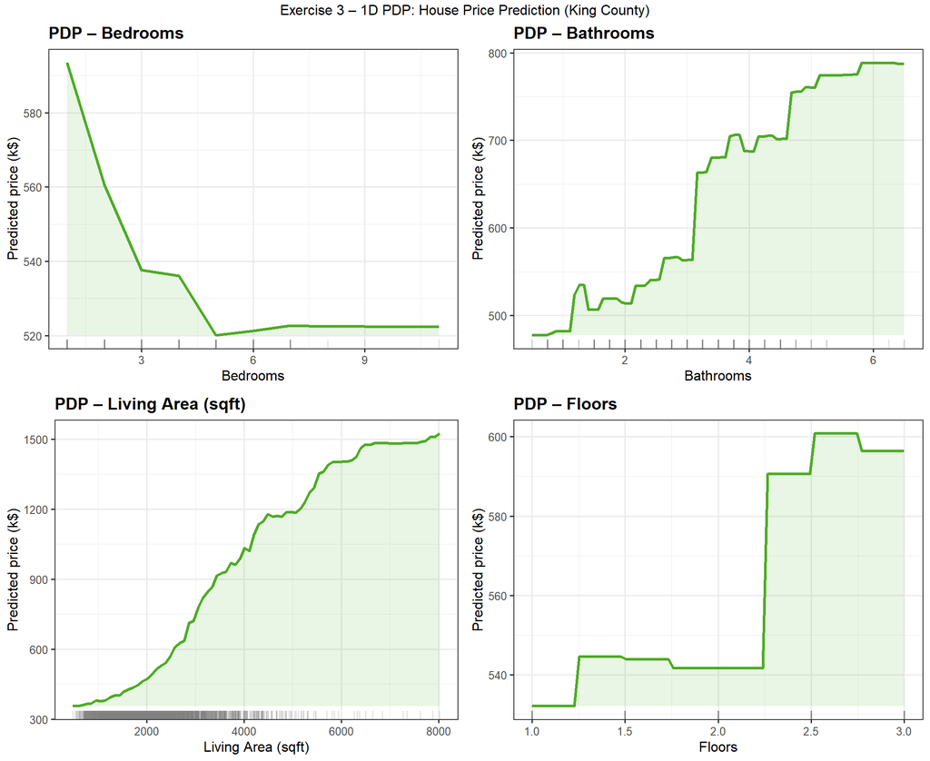

```r
plot_pdp_house <- function(feature, label) {
  pd <- partial(rf_house, pred.var = feature,
                train = kc_sample[, features_house], grid.resolution = 80)
  pd$yhat_k <- pd$yhat / 1000

  ggplot(pd, aes_string(x = feature, y = "yhat_k")) +
    geom_line(color = "#4DAC26", linewidth = 1.2) +
    geom_ribbon(aes(ymin = min(yhat_k), ymax = yhat_k),
                alpha = 0.12, fill = "#4DAC26") +
    geom_rug(data = kc_sample, aes_string(x = feature), sides = "b",
             inherit.aes = FALSE, alpha = 0.2, color = "gray50") +
    labs(title = paste("PDP –", label),
         x = label, y = "Predicted price (k$)") +
    theme_bw(base_size = 12) +
    theme(plot.title = element_text(face = "bold"))
}

p1h <- plot_pdp_house("bedrooms",    "Bedrooms")
p2h <- plot_pdp_house("bathrooms",   "Bathrooms")
p3h <- plot_pdp_house("sqft_living", "Living Area (sqft)")
p4h <- plot_pdp_house("floors",      "Floors")

grid.arrange(p1h, p2h, p3h, p4h, ncol = 2,
             top = "Exercise 3 – 1D PDP: House Price Prediction (King County)")
```

## Analysis

**Floors:** Moderate positive effect. Two-storey homes command higher prices than single-storey, reflecting larger total area and design preferences. Slight uncertainty at 3+ floors due to limited observations.